# Time Series Homework: Chapter 6 Lesson 2

Tristan Farrow

## Data

```r
gdp_ts <- rio::import("https://byuistats.github.io/timeseries/data/gdp_fred.csv") |>
  mutate(year_over_year = gdp_millions / lag(gdp_millions, 4)-1) |>
  mutate(quarter = yearquarter(mdy(quarter))) |>
  filter(quarter >= yearquarter(my("Jan 1990")) & quarter < yearquarter(my("Jan 2025"))) |>
  na.omit() |>
  mutate(t = 1:n()) |>
  mutate(std_t = (t - mean(t)) / sd(t)) |>
  as_tsibble(index = quarter)
```

## Questions

### Question 1 - Stationary Model Comparison (20 points)

We have worked with AR(p), MA(q), ARMA(p,q) stochastic processes. The theoretical ACF and PACF functions of each model can help us identify which of the three models would be a good fit for a particular time series. From the Time Series Notebook:

**NoteACF and PACF of an $AR(p)$ Process**

|  | AR(p) | MA(q) | ARMA(p,q) |
| --- | --- | --- | --- |
| ACF | Tails off | Cuts off after lag $q$ | Tails off |
| PACF | Cuts off after lag $p$ | Tails off | Tails off |

In the pprevious assignment, you worked with a simulation of a AR(3) process and a MA(3) process. In this assignment you will be comparing your findings from that assignment to an ARMA(3,3) process.

#### ARMA(3,3) Simulation

```r
n <- 10000  # Number of observations
ar_coeffs <- c(0.5, 0.3, 0.1)   # AR coefficients
ma_coeffs <- c(-0.7, -0.5, 0.2)  # MA coefficients

# Simulate the ARMA(3, 3) process
set.seed(123)  # For reproducibility
arma33_process <- arima.sim(n = n, model = list(ar = ar_coeffs, ma = ma_coeffs), sd = 1)

# Convert the simulated ARMA(3, 3) process to a tsibble
arma_33 <- as_tsibble(tibble(Time = 1:n, value = arma33_process), index = Time)
```

##### a) Plot the ACFs for the ARMA(3) simulation.

**NoteAnswer**

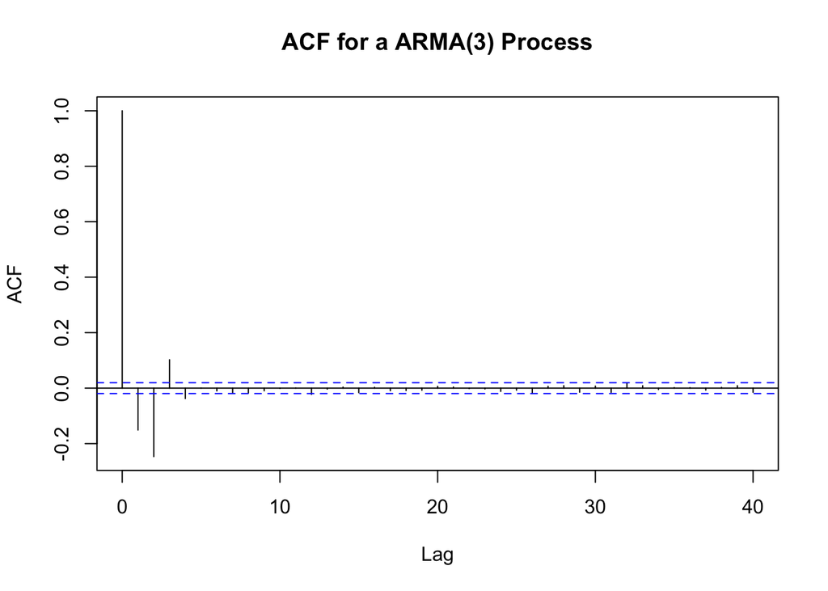

```r
acf(arma_33, main = "ACF for a ARMA(3) Process")
```

##### b) Plot the PACFs for the ARMA(3) simulation.

**NoteAnswer**

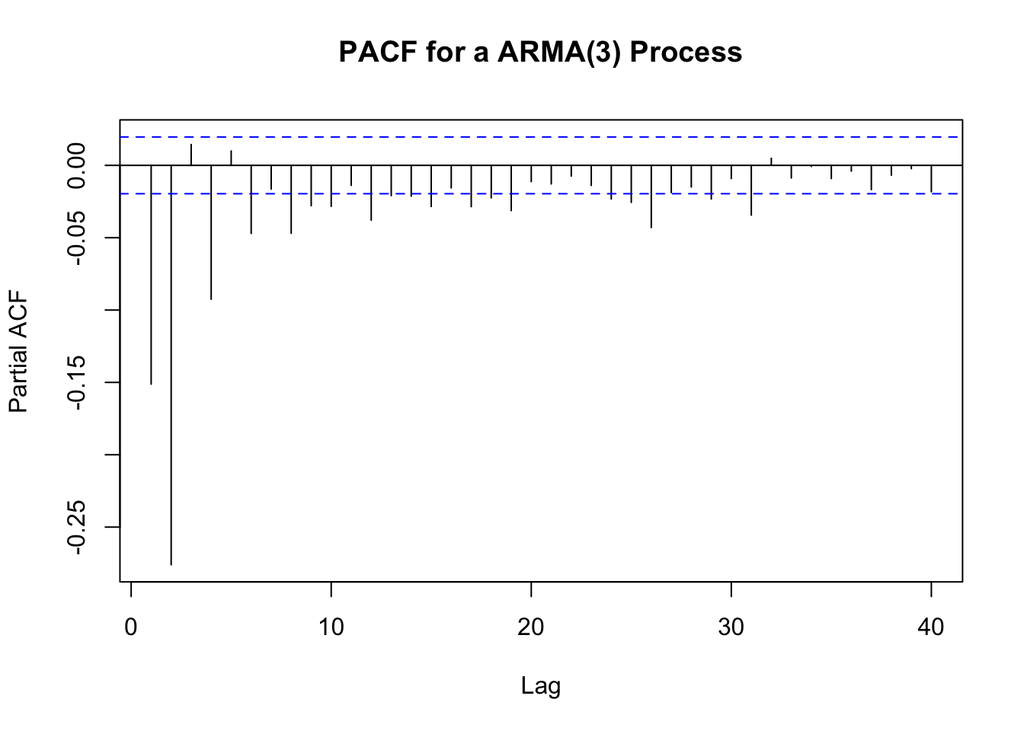

```r
pacf(arma_33, main = "PACF for a ARMA(3) Process")
```

### Question 2 - ARMA(p,q): GDP Business Cycles (50 points)

Business cycles are the fluctuations in economic activity that an economy experiences over time, marked by phases of expansion, peak, contraction (or recession), and trough. During expansion, economic indicators such as GDP rise, reaching a peak where the economy operates at maximum capacity. Following the peak, the economy contracts, leading to a recession characterized by falling GDP, until it hits a trough, the lowest point, signaling the end of contraction and the start of recovery. The yearly percentage change in real GDP effectively captures the fluctuations of business cycles by quantifying the rate at which an economy’s total output of goods and services grows or shrinks from one year to the next. The yearly percentage change in real US GDP in decimals is the `year_over_year` variable in the `gdp_ts` tsibble.

##### a) Plot the yearly percentage change in US Real GDP

**NoteAnswer**

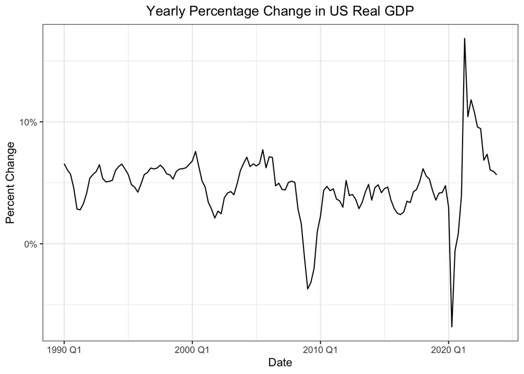

```r
ggplot(gdp_ts, aes(x = quarter, y = year_over_year)) +
  geom_line() +
  labs(
    title = "Yearly Percentage Change in US Real GDP",
    x = "Date",
    y = "Percent Change"
  ) +
  scale_y_continuous(
    labels = scales::label_percent()
  ) +
  theme_bw() +
  theme(
    plot.title = element_text(hjust = 0.5)
  )
```

##### b) Plot the ACF and PACF of the series

**NoteAnswer**

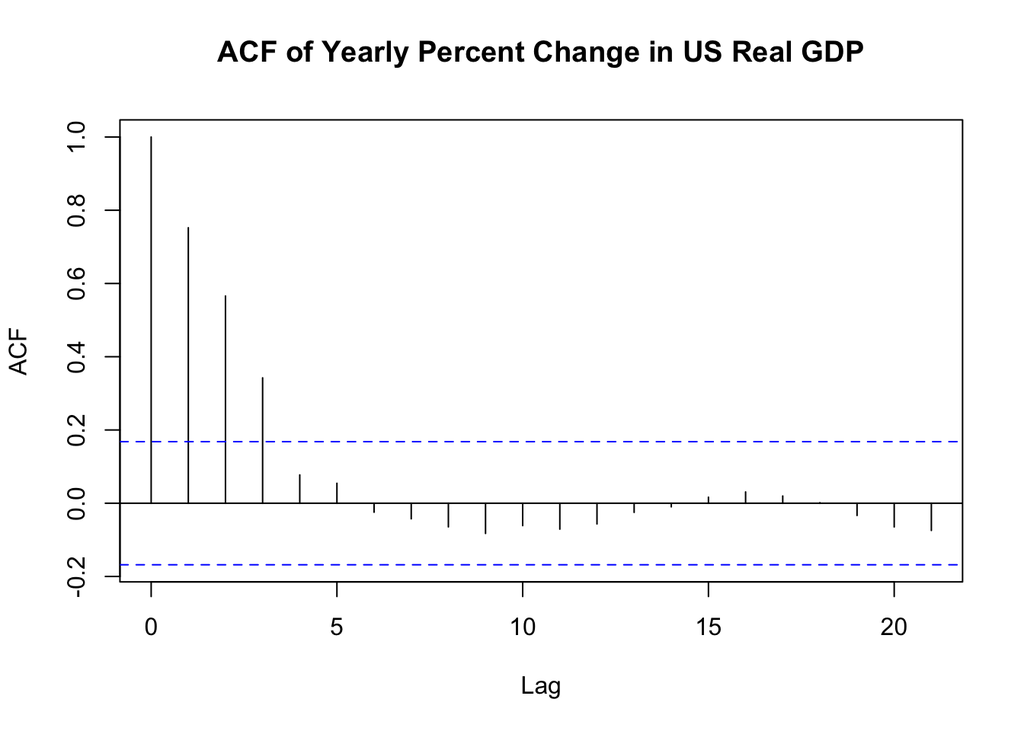

```r
acf(gdp_ts$year_over_year, main = "ACF of Yearly Percent Change in US Real GDP")
```

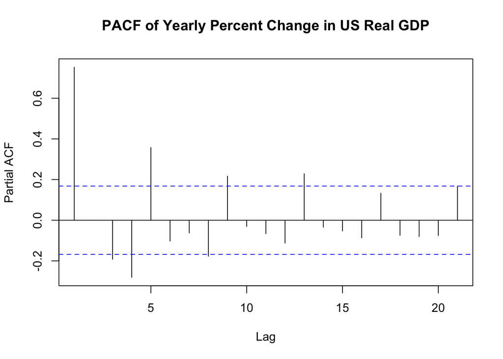

```r
pacf(gdp_ts$year_over_year, main = "PACF of Yearly Percent Change in US Real GDP")
```

##### c) Based on the ACF and PACF, please speculate which stationary model will best fit the data.

**NoteAnswer**

##### d) Please fit an AR(p) model to the yearly percentage change in US Real GDP.

**NoteAnswer**

```r
gdp_ar <- gdp_ts %>%
  model(ar = ARIMA(year_over_year ~ 1 + pdq(4, 0, 0) + PDQ(0, 0, 0)))

tidy(gdp_ar)
```

```
# A tibble: 5 × 6
  .model term     estimate std.error statistic  p.value
  <chr>  <chr>       <dbl>     <dbl>     <dbl>    <dbl>
1 ar     ar1        0.695    0.0816      8.52  2.63e-14
2 ar     ar2        0.185    0.101       1.83  7.02e- 2
3 ar     ar3        0.0210   0.101       0.208 8.35e- 1
4 ar     ar4       -0.279    0.0814     -3.43  8.12e- 4
5 ar     constant   0.0181   0.00140    13.0   1.56e-25
```

##### e) Please fit an MA(q) model to the yearly percentage change in US Real GDP.

**NoteAnswer**

```r
gdp_ma <- gdp_ts %>%
  model(ma = ARIMA(year_over_year ~ 1 + pdq(0, 0, 4) + PDQ(0, 0, 0)))

tidy(gdp_ma)
```

```
# A tibble: 5 × 6
  .model term     estimate std.error statistic  p.value
  <chr>  <chr>       <dbl>     <dbl>     <dbl>    <dbl>
1 ma     ma1        0.927    0.0778     11.9   7.14e-23
2 ma     ma2        0.959    0.0836     11.5   9.80e-22
3 ma     ma3        0.908    0.0871     10.4   4.78e-19
4 ma     ma4       -0.0575   0.0789     -0.729 4.67e- 1
5 ma     constant   0.0479   0.00410    11.7   2.89e-22
```

##### f) Please fit an ARMA(p,q) model to the yearly percentage change in US Real GDP.

**NoteAnswer**

```r
gdp_arma <- gdp_ts |>
  model(ma = ARIMA(year_over_year ~ 1 + pdq(0,0,4) + PDQ(0, 0, 0)))

tidy(gdp_arma)
```

```
# A tibble: 5 × 6
  .model term     estimate std.error statistic  p.value
  <chr>  <chr>       <dbl>     <dbl>     <dbl>    <dbl>
1 ma     ma1        0.927    0.0778     11.9   7.14e-23
2 ma     ma2        0.959    0.0836     11.5   9.80e-22
3 ma     ma3        0.908    0.0871     10.4   4.78e-19
4 ma     ma4       -0.0575   0.0789     -0.729 4.67e- 1
5 ma     constant   0.0479   0.00410    11.7   2.89e-22
```

##### g) In a table, please compare the fit of each model. Which do you think is the best model for the series?

**NoteAnswer**

```r
all_models <- gdp_ts |>
  model(
    ar = ARIMA(year_over_year ~ 1 + pdq(4,0,0) + PDQ(0, 0, 0)),
    ma = ARIMA(year_over_year ~ 1 + pdq(0,0,4) + PDQ(0, 0, 0)),
    arma = ARIMA(year_over_year ~ 1 + pdq(4,0,4) + PDQ(0, 0, 0))
  )

glance(all_models)
```

```
# A tibble: 3 × 8
  .model   sigma2 log_lik   AIC  AICc   BIC ar_roots  ma_roots
  <chr>     <dbl>   <dbl> <dbl> <dbl> <dbl> <list>    <list>
1 ar     0.000275    367. -721. -720. -704. <cpl [4]> <cpl [0]>
2 ma     0.000173    394. -775. -774. -758. <cpl [0]> <cpl [4]>
3 arma   0.000161    398. -777. -775. -747. <cpl [4]> <cpl [4]>
```

### Rubric

[output not shown]